# Sushi Rankings Analysis

Voting rules, agreement, and preference clustering

Published

April 20, 2026

## Summary of Findings

### Part 1 — Most popular sushi options

All three voting methods point to the same winner:

- **First-preference leader:** fatty tuna (1713 first-place votes, 34.3% of respondents).
- **IRV winner:** fatty tuna (survived all elimination rounds).
- **Condorcet winner:** fatty tuna.

The three methods **agree**: *fatty tuna* is unambiguously the most popular sushi option in this dataset. *Cucumber roll* consistently appears at the bottom across all voting rules.

### Part 2 — Agreement among respondents

Kendall’s coefficient of concordance is **W = 0.192** (weak agreement), which is highly statistically significant (χ²(9) = 8625.4, *p* < 0.001). Respondents show non-random, consistent preferences for sushi — the agreement is real, not an artefact of chance.

### Part 3 — Preference clusters

A Gaussian mixture model (mclust, model VVV) selected **K = 3 clusters** based on BIC. Each respondent has a posterior probability of belonging to each cluster. Key clusters:

- Cluster 1 (1058 respondents, 21.2%): prefers sea urchin and fatty tuna; likes cucumber roll least.
- Cluster 2 (2158 respondents, 43.2%): prefers shrimp and tuna; likes cucumber roll least.
- Cluster 3 (1784 respondents, 35.7%): prefers fatty tuna and tuna; likes cucumber roll least.

Respondents are assigned **probabilistically** — most belong predominantly to one cluster, but the soft membership captures genuine uncertainty for borderline cases.

## Setup and Data

```r
cat("Dimensions:", dim(sushi), "\n")
```

```
Dimensions: 5000 10
```

```r
cat("Items:", paste(items, collapse = ", "), "\n")
```

```
Items: shrimp, sea eel, tuna, squid, sea urchin, salmon roe, egg, fatty tuna, tuna roll, cucumber roll
```

```r
head(sushi, 3) |> kable(caption = "First 3 rows of sushi_rankings (1 = most preferred)")
```

First 3 rows of sushi_rankings (1 = most preferred)

| shrimp | sea eel | tuna | squid | sea urchin | salmon roe | egg | fatty tuna | tuna roll | cucumber roll |
| --- | --- | --- | --- | --- | --- | --- | --- | --- | --- |
| 2 | 8 | 10 | 3 | 4 | 1 | 5 | 9 | 7 | 6 |
| 1 | 8 | 6 | 4 | 10 | 9 | 3 | 5 | 7 | 2 |
| 2 | 8 | 3 | 4 | 6 | 7 | 10 | 1 | 5 | 9 |

The data (`BayesMallows::sushi_rankings`) contains **5000 respondents** who each ranked **10 sushi types** from 1 (most preferred) to 10 (least preferred). The sushi types are: shrimp, sea eel, tuna, squid, sea urchin, salmon roe, egg, fatty tuna, tuna roll, cucumber roll.

## Part 1 — Most Popular Options

### First-preference counts

```r
fp_df |>
  mutate(Proportion = scales::percent(Proportion, accuracy = 0.1)) |>
  kable(caption = "First-place vote counts per sushi item (sorted descending)")
```

First-place vote counts per sushi item (sorted descending)

| Item | Count | Proportion |
| --- | --- | --- |
| fatty tuna | 1713 | 34.3% |
| sea urchin | 747 | 14.9% |
| sea eel | 550 | 11.0% |
| salmon roe | 545 | 10.9% |
| shrimp | 458 | 9.2% |
| tuna | 404 | 8.1% |
| squid | 228 | 4.6% |
| egg | 206 | 4.1% |
| tuna roll | 113 | 2.3% |
| cucumber roll | 36 | 0.7% |

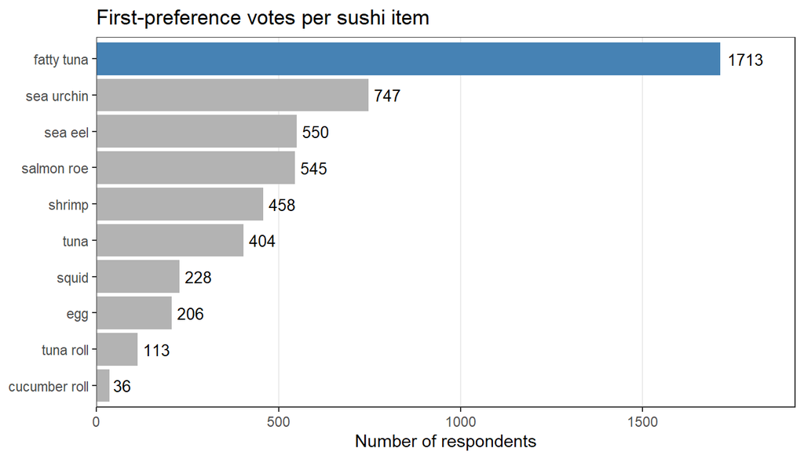

```r
fp_df |>
  mutate(Item = fct_reorder(Item, Count)) |>
  ggplot(aes(x = Item, y = Count,
             fill = Item == fp_winner)) +
  geom_col(show.legend = FALSE) +
  scale_fill_manual(values = c("grey70", "steelblue")) +
  geom_text(aes(label = Count), hjust = -0.2, size = 3.5) +
  scale_y_continuous(expand = expansion(mult = c(0, 0.12))) +
  coord_flip() +
  labs(
    title = "First-preference votes per sushi item",
    x = NULL, y = "Number of respondents"
  ) +
  theme_bw() +
  theme(panel.grid.major.y = element_blank(),
        panel.grid.minor   = element_blank())
```

**fatty tuna** received the most first-place votes (1713, 34.3% of respondents).

### Instant-Runoff Voting (IRV)

```r
irv_round_df <- map_dfr(seq_along(irv_res$rounds), function(i) {
  r <- irv_res$rounds[[i]]
  tibble(Round = i, Item = names(r), Votes = as.integer(r))
})

irv_wide <- irv_round_df |>
  pivot_wider(names_from = Round, values_from = Votes,
              names_prefix = "Round ") |>
  arrange(desc(`Round 1`))

kable(irv_wide, caption = "IRV vote tallies by round (NA = already eliminated)")
```

IRV vote tallies by round (NA = already eliminated)

| Item | Round 1 | Round 2 | Round 3 | Round 4 | Round 5 | Round 6 | Round 7 | Round 8 |
| --- | --- | --- | --- | --- | --- | --- | --- | --- |
| fatty tuna | 1713 | 1716 | 1752 | 1795 | 1852 | 2075 | 2371 | 2754 |
| sea urchin | 747 | 748 | 755 | 762 | 778 | 811 | 962 | 1120 |
| sea eel | 550 | 554 | 570 | 613 | 649 | 728 | 802 | NA |
| salmon roe | 545 | 546 | 556 | 577 | 602 | 660 | NA | NA |
| shrimp | 458 | 467 | 474 | 525 | 619 | 726 | 865 | 1126 |
| tuna | 404 | 409 | 434 | 466 | 500 | NA | NA | NA |
| squid | 228 | 230 | 242 | 262 | NA | NA | NA | NA |
| egg | 206 | 211 | 217 | NA | NA | NA | NA | NA |
| tuna roll | 113 | 119 | NA | NA | NA | NA | NA | NA |
| cucumber roll | 36 | NA | NA | NA | NA | NA | NA | NA |

```r
if (length(irv_res$eliminated) > 0) {
  cat("Elimination sequence:", paste(irv_res$eliminated, collapse = " → "), "\n")
} else {
  cat("No eliminations needed — a majority was reached in Round 1.\n")
}
```

```
Elimination sequence: cucumber roll → tuna roll → egg → squid → tuna → salmon roe → sea eel
```

```r
cat("IRV winner:", irv_winner)
```

```
IRV winner: fatty tuna
```

The **IRV winner is fatty tuna**, consistent with its dominant first-preference share.

### Condorcet analysis

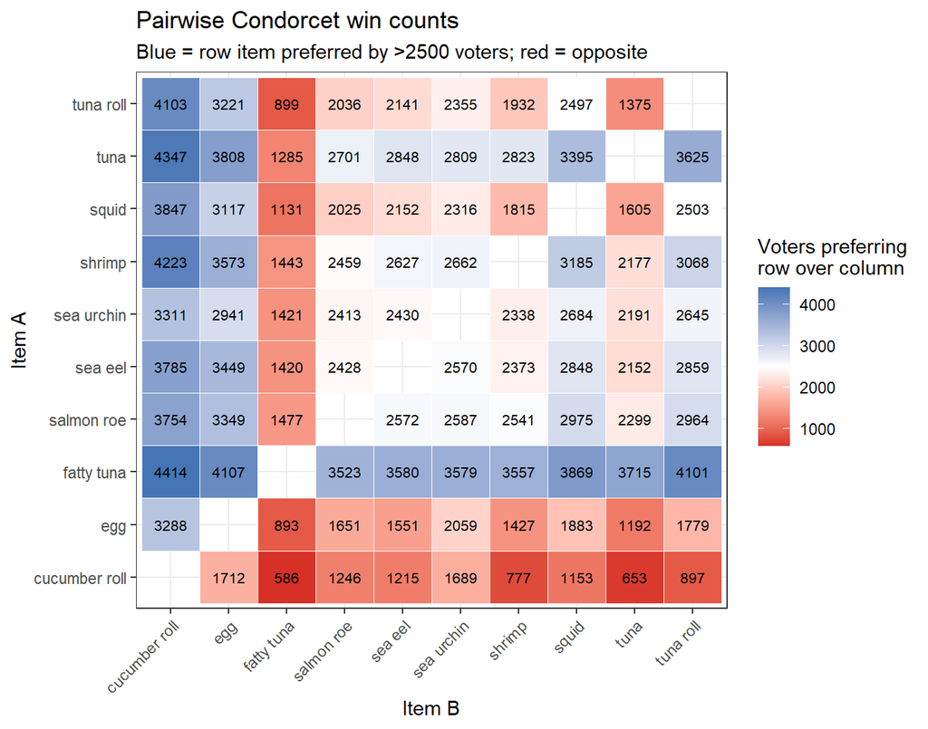

```r
# Show pairwise win matrix as a heatmap
pw_df <- as_tibble(pw_wins, rownames = "Item_A") |>
  pivot_longer(-Item_A, names_to = "Item_B", values_to = "Wins") |>
  filter(Item_A != Item_B) |>
  mutate(Majority = Wins > n_voters / 2)

ggplot(pw_df, aes(x = Item_B, y = Item_A, fill = Wins)) +
  geom_tile(colour = "white") +
  geom_text(aes(label = Wins), size = 2.8) +
  scale_fill_gradient2(
    low = "#d73027", mid = "white", high = "#4575b4",
    midpoint = n_voters / 2,
    name = "Voters preferring\nrow over column"
  ) +
  labs(
    title = "Pairwise Condorcet win counts",
    subtitle = paste0("Blue = row item preferred by >", n_voters/2, " voters; red = opposite"),
    x = "Item B", y = "Item A"
  ) +
  theme_bw() +
  theme(axis.text.x = element_text(angle = 45, hjust = 1))
```

```r
if (!is.na(condorcet_winner)) {
  cat("Condorcet winner:", condorcet_winner, "\n")
  cat(condorcet_winner, "beats every other item in head-to-head comparisons.\n")
} else {
  cat("No Condorcet winner exists (preference cycles detected).\n")
  if (!is.null(cycle_example)) {
    cat("Example cycle:", cycle_example[1], "beats", cycle_example[2],
        ",", cycle_example[2], "beats", cycle_example[3],
        ", but", cycle_example[3], "beats", cycle_example[1], "\n")
  }
}
```

```
Condorcet winner: fatty tuna
fatty tuna beats every other item in head-to-head comparisons.
```

**fatty tuna** beats every other sushi item in direct head-to-head pairwise comparisons.

## Part 2 — Agreement vs Randomness (Kendall’s W)

### Method

Kendall’s coefficient of concordance $W$ measures the degree of agreement among $m$ judges ranking $n$ items:

$$W = \frac{12S}{m^2(n^3 - n)}$$

where $S = \sum_{j=1}^{n}(R_j - \bar{R})^2$ is the sum of squared deviations of column rank sums from their expected value under randomness ($\bar{R} = m(n+1)/2$). Under the null hypothesis of random rankings, $m(n-1)W \sim \chi^2_{n-1}$ (large-sample approximation).

```r
kendall_tbl <- tibble(
  Statistic = c("m (judges)", "n (items)", "W", "χ² statistic", "df", "p-value"),
  Value     = c(m, n,
                round(W, 4),
                round(chi_sq_W, 2),
                df_W,
                format.pval(p_W, digits = 3, eps = 1e-15))
)
kable(kendall_tbl, caption = "Kendall's W results")
```

Kendall’s W results

| Statistic | Value |
| --- | --- |
| m (judges) | 5000 |
| n (items) | 10 |
| W | 0.1917 |
| χ² statistic | 8625.42 |
| df | 9 |
| p-value | <1e-15 |

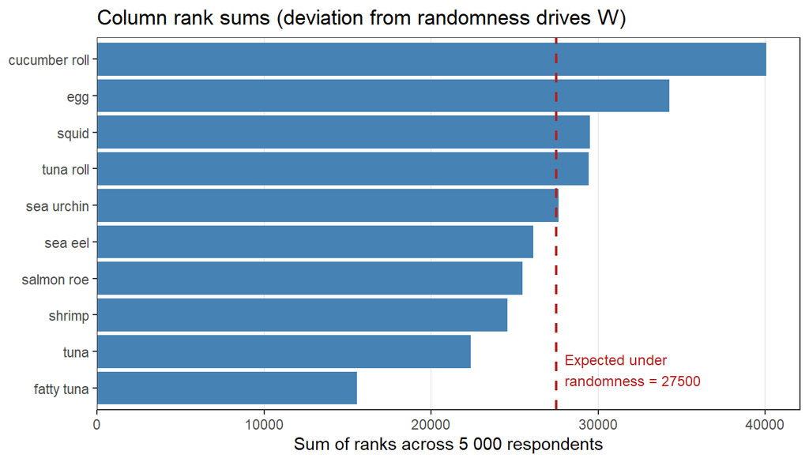

```r
tibble(Item = items, RankSum = R_j) |>
  mutate(Item = fct_reorder(Item, RankSum)) |>
  ggplot(aes(x = Item, y = RankSum)) +
  geom_col(fill = "steelblue") +
  geom_hline(yintercept = R_bar, linetype = "dashed", colour = "firebrick",
             linewidth = 0.8) +
  annotate("text", x = 1.5, y = R_bar + 500,
           label = paste("Expected under\nrandomness =", R_bar),
           colour = "firebrick", size = 3.2, hjust = 0) +
  scale_y_continuous(expand = expansion(mult = c(0, 0.05))) +
  coord_flip() +
  labs(title = "Column rank sums (deviation from randomness drives W)",
       x = NULL, y = "Sum of ranks across 5 000 respondents") +
  theme_bw() +
  theme(panel.grid.major.y = element_blank(),
        panel.grid.minor   = element_blank())
```

### Interpretation

$W = 0.192$ indicates **weak agreement** among the 5 000 respondents. The chi-squared test strongly rejects the null hypothesis of random rankings ($\chi^2(9) = 8625.4$, $p < 0.001$). While a perfect $W = 1$ is rare for large groups with diverse tastes, the observed level of concordance confirms that sushi preferences are **non-random and consistent across respondents** — fatty tuna and tuna are broadly liked, while cucumber roll and egg are broadly disliked.

## Part 3 — Clustering with Probabilistic Class Membership

### Model choice

We use **Gaussian Mixture Models (GMM)** via the `mclust` R package (Scrucca et al., 2023). Although the data are rankings rather than continuous measurements, GMMs applied to rank matrices are a well-established general-purpose latent class approach that directly yields posterior class membership probabilities for each respondent. `mclust` selects the covariance structure automatically via BIC.

> *Justification:* `mclust` handles multivariate continuous (or rank-as-continuous) data and provides exact posterior probabilities $P(\text{cluster } k \mid \text{ranking}_i)$ via the E-step of the EM algorithm — exactly what this analysis requires.

### Number of clusters (BIC)

```r
kable(bic_table, caption = "mclust BIC by number of clusters K (higher = better)")
```

mclust BIC by number of clusters K (higher = better)

| K | BIC | Selected |
| --- | --- | --- |
| 1 | -212417.2 |  |
| 2 | -208979.9 |  |
| 3 | -207058.0 | ✓ |
| 4 | -207285.9 |  |

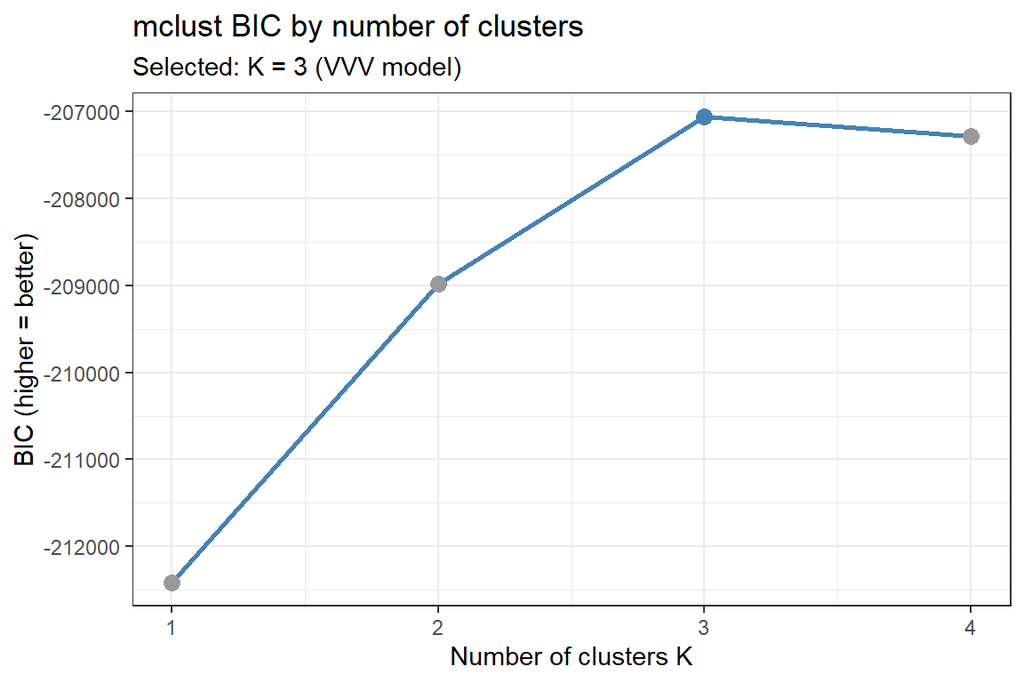

```r
bic_table |>
  ggplot(aes(x = K, y = BIC)) +
  geom_line(colour = "steelblue", linewidth = 1) +
  geom_point(aes(colour = K == best_G), size = 3, show.legend = FALSE) +
  scale_colour_manual(values = c("grey60", "steelblue")) +
  labs(title = "mclust BIC by number of clusters",
       subtitle = paste0("Selected: K = ", best_G, " (", best_model, " model)"),
       x = "Number of clusters K", y = "BIC (higher = better)") +
  theme_bw()
```

`mclust` selected **K = 3** clusters (model VVV) as the highest-BIC solution.

### Cluster sizes

```r
kable(cl_sizes, caption = paste0("Respondent counts per cluster (K = ", best_G, ")"))
```

Respondent counts per cluster (K = 3)

| Cluster | Count | Proportion |
| --- | --- | --- |
| 1 | 1058 | 0.212 |
| 2 | 2158 | 0.432 |
| 3 | 1784 | 0.357 |

### Average ranks per cluster

Lower values indicate stronger preference (rank 1 = most preferred).

```r
avg_rank_df <- map_dfr(seq_len(best_G), function(k) {
  tibble(Cluster = paste0("Cluster ", k),
         Item    = items,
         AvgRank = cl_avg_ranks[[k]])
})

avg_rank_wide <- avg_rank_df |>
  pivot_wider(names_from = Cluster, values_from = AvgRank) |>
  mutate(across(where(is.numeric), ~round(.x, 2))) |>
  arrange(`Cluster 1`)

kable(avg_rank_wide,
      caption = "Average rank per item per cluster (lower = more preferred)")
```

Average rank per item per cluster (lower = more preferred)

| Item | Cluster 1 | Cluster 2 | Cluster 3 |
| --- | --- | --- | --- |
| sea urchin | 2.00 | 6.13 | 6.88 |
| fatty tuna | 2.04 | 5.10 | 1.34 |
| salmon roe | 3.51 | 5.28 | 5.81 |
| tuna | 5.14 | 4.95 | 3.50 |
| sea eel | 5.19 | 4.97 | 5.56 |
| shrimp | 5.45 | 4.33 | 5.31 |
| squid | 6.68 | 5.23 | 6.24 |
| tuna roll | 6.81 | 5.89 | 5.34 |
| egg | 8.77 | 6.00 | 6.75 |
| cucumber roll | 9.40 | 7.12 | 8.27 |

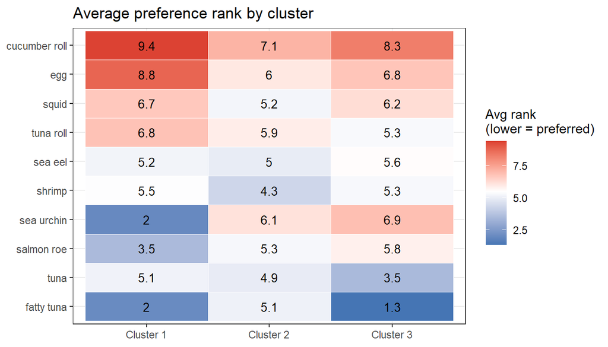

```r
avg_rank_df |>
  mutate(Item = fct_reorder(Item, AvgRank, .fun = mean)) |>
  ggplot(aes(x = Cluster, y = Item, fill = AvgRank)) +
  geom_tile(colour = "white") +
  geom_text(aes(label = round(AvgRank, 1)), size = 3.5) +
  scale_fill_gradient2(
    low  = "#4575b4",
    mid  = "white",
    high = "#d73027",
    midpoint = (n_items + 1) / 2,
    name = "Avg rank\n(lower = preferred)"
  ) +
  labs(title = "Average preference rank by cluster",
       x = NULL, y = NULL) +
  theme_bw()
```

### Top 3 items per cluster

```r
tibble(
  Cluster = paste0("Cluster ", seq_len(best_G)),
  `Count (n)` = cl_sizes$Count,
  `Top 3 most preferred` = top3_per_cluster
) |> kable(caption = "Most preferred sushi items per cluster")
```

Most preferred sushi items per cluster

| Cluster | Count (n) | Top 3 most preferred |
| --- | --- | --- |
| Cluster 1 | 1058 | sea urchin, fatty tuna, salmon roe |
| Cluster 2 | 2158 | shrimp, tuna, sea eel |
| Cluster 3 | 1784 | fatty tuna, tuna, shrimp |

### Posterior membership probabilities (sample)

The matrix below shows the first 10 respondents’ posterior probabilities of belonging to each cluster ($\sum_k P_k = 1$ per row).

```r
z_matrix |>
  as_tibble(.name_repair = "unique") |>
  setNames(paste0("P(Cluster ", seq_len(best_G), ")")) |>
  mutate(
    Respondent = seq_len(n_voters),
    `Hard assignment` = cl_assign
  ) |>
  select(Respondent, `Hard assignment`, everything()) |>
  slice_head(n = 10) |>
  mutate(across(starts_with("P("), ~round(.x, 3))) |>
  kable(caption = "Posterior cluster membership probabilities (first 10 respondents)")
```

Posterior cluster membership probabilities (first 10 respondents)

| Respondent | Hard assignment | P(Cluster 1) | P(Cluster 2) | P(Cluster 3) |
| --- | --- | --- | --- | --- |
| 1 | 2 | 0.000 | 1.000 | 0.000 |
| 2 | 2 | 0.000 | 1.000 | 0.000 |
| 3 | 3 | 0.000 | 0.024 | 0.976 |
| 4 | 1 | 0.994 | 0.005 | 0.000 |
| 5 | 2 | 0.000 | 1.000 | 0.000 |
| 6 | 2 | 0.000 | 1.000 | 0.000 |
| 7 | 1 | 0.895 | 0.018 | 0.087 |
| 8 | 2 | 0.000 | 1.000 | 0.000 |
| 9 | 2 | 0.000 | 0.994 | 0.006 |
| 10 | 2 | 0.000 | 1.000 | 0.000 |

### Cluster descriptions

```r
map_dfr(seq_len(best_G), function(k) {
  avg_r   <- cl_avg_ranks[[k]]
  ord     <- order(avg_r)
  top3    <- names(avg_r)[ord[1:3]]
  bottom2 <- names(avg_r)[ord[(n_items-1):n_items]]
  tibble(
    Cluster    = paste0("Cluster ", k),
    n          = cl_sizes$Count[k],
    `%`        = paste0(round(cl_sizes$Proportion[k]*100, 1), "%"),
    `Top 3 (most preferred)` = paste(top3, collapse = " > "),
    `Bottom 2 (least preferred)` = paste(bottom2, collapse = " > ")
  )
}) |> kable(caption = "Plain-language cluster profiles")
```

Plain-language cluster profiles

| Cluster | n | % | Top 3 (most preferred) | Bottom 2 (least preferred) |
| --- | --- | --- | --- | --- |
| Cluster 1 | 1058 | 21.2% | sea urchin > fatty tuna > salmon roe | egg > cucumber roll |
| Cluster 2 | 2158 | 43.2% | shrimp > tuna > sea eel | sea urchin > cucumber roll |
| Cluster 3 | 1784 | 35.7% | fatty tuna > tuna > shrimp | sea urchin > cucumber roll |